# Project 131

## Introduction

Employees are the valuable assets of any organization or enterprise, they can create huge profits for the organization or enterprise. If an enterprise wants to develop better, it must find a way how to retain employees and reduce employee attrition. Employee attrition can be for voluntary or involuntary reasons, such as retirement, as well as resignation and contract termination.  
If a lot of employees leave for involuntary reasons, it can damage a company’s reputation, cost it valuable time and money, and lead to low morale among employees.  
It is important for any enterprise or organization to monitor employee attrition rate and understand why employees leave if the enterprise or organization want to avoid negative impacts.  
In this project, the IBM HR Employee Attrition data is used to analyzed various factors that lead to employee attrition from the company and predict the attrition of an employee based on the various variables given and different models. The data can be downloaded from Kaggle. The url is shown as below:  
https://www.kaggle.com/datasets/noordeen/employee-attrition  
The IBM HR Employee Attrition data contains 1470 cases and 35 variables related to the employees’ features. Each case represents an employee. The dependent variable (Y) is Attrition, means Employee leaving the company (0=no,1=yes). The other 34 variables are chosen as independent variables (X) to explain and predict the dependent variable Attrition (Y).  
As this project focuses on the classification problem, we use “Accuracy” as the summary metric to select the optimal model.  
Once we have an optimal classification model, an enterprise or organization like IBM can predict and implement solutions to reduce employee attrition and stabilize work culture.

## Loading Packages and Data

```r
library(tidyverse)
library(lubridate)
library(dplyr)
library(ggplot2)
library(readr)
library(GGally)
library(ISLR)
library(tree)
library(MASS)
library(randomForest)
library(boot)
library(caret)
library(rpart)
library(rpart.plot)
library(gbm)
library(tidymodels)
```

```r
#load data
EmployeeData<-read_csv("HR-Employee-Attrition.csv")
```

The detailed description of all the variables in the data is shown as below:  
**Age**: Age of Employee  
**Attrition**: Employee leaving the company (0=no,1=yes)  
**Business Travel**: Employee traveling level (1=No Travel, 2=Travel Frequently, 3=Tavel Rarely)  
**Daily Rate**: Salary level of employee  
**Department**: Department of Employee (1=HR, 2=R&D, 3=Sales)  
**Distance From Home**: The distance from work to home  
**Education**: Employee’s education level (1= Below College, 2= College, 3= Bachelor, 4= Master, 5= Doctor)  
**Education Field**: Employee’s field of Education (1=HR, 2=LIFE SCIENCES, 3=MARKETING, 4=MEDICAL SCIENCES, 5=OTHERS, 6= TEHCNICAL)  
**Employee Count**: Count of Employee  
**Employee Number**: Employee ID  
**Environment Satisfaction**: Satisfaction with Environment (1=Low, 2=Medium ,3=High, 4=Very,5= High)  
**Gender**: Employee Gender (1=FEMALE, 2=MALE) **Hourly Rate**: Employee Hourly Salary  
**Job Involvement**: Job involvement (1=Low ,2=Medium, 3=High, 4=Very High)  
**Job Level**: Employee’s level of job  
**Job Role**: Employee’s Job Role (1=HC REP, 2=HR, 3=LAB TECHNICIAN, 4=MANAGER, 5= MANAGING DIRECTOR, 6= REASEARCH DIRECTOR, 7= RESEARCH SCIENTIST, 8=SALES EXECUTIEVE, 9= SALES REPRESENTATIVE)  
**Job Satisfaction**: Employees Job Satisfaction (1=Low, 2=Medium, 3=High, 4=Very High)  
**Martial Status**: Employee’s Martial Status (1=DIVORCED, 2=MARRIED, 3=SINGLE) Monthly Rate Employee’s Monthly salary  
**Monthly Income**: Employee’s Monthly Income **NumCompanies**: Worked No. of companies worked at  
**Over 18**: Is employee 18 years old? (1=Yes, 2=No)  
**Overtime**: Does employee work overtime? (1=No, 2=Yes)  
**Percent Salary Hike**: Employee’s percentage increase in salary  
**Performance Rating**: Employee’s performance rating (1=Low, 2=Good, 3=Excellent, 4=Outstanding)  
**Relations Satisfaction**: Employee’s relations satisfaction (1=Low, 2=Medium, 3=High, 4=Very High)  
**Standard Hours**: Employee’s Standard working hours  
**Stock Options Level**: Employee’s stock options  
**Total Working Years**: Employee total years worked  
**Training Times Last Year**: Employee training hours  
**Work Life Balance**: Employee’s time spent between work and outside (1=Bad, 2=Good,3=Better, 4=Best)  
**Years at company**: Employee’s total nuber of years at company  
**Years in Current Role**: Employee’s number of years in current role  
**Years since Last Promotion**: Number of years since last promotion  
**Years with Current Manager**: Number of years spent with current manager

The description of these columns is also shown in the codebook.

## Data Cleaning

Check if there are any NA values in the data. As is shown below, there is no missing value in all the variables.

```r
apply(is.na(EmployeeData), MARGIN = 2, sum)
```

```
##                      Age                Attrition           BusinessTravel
##                        0                        0                        0
##                DailyRate               Department         DistanceFromHome
##                        0                        0                        0
##                Education           EducationField            EmployeeCount
##                        0                        0                        0
##           EmployeeNumber  EnvironmentSatisfaction                   Gender
##                        0                        0                        0
##               HourlyRate           JobInvolvement                 JobLevel
##                        0                        0                        0
##                  JobRole          JobSatisfaction            MaritalStatus
##                        0                        0                        0
##            MonthlyIncome              MonthlyRate       NumCompaniesWorked
##                        0                        0                        0
##                   Over18                 OverTime        PercentSalaryHike
##                        0                        0                        0
##        PerformanceRating RelationshipSatisfaction            StandardHours
##                        0                        0                        0
##         StockOptionLevel        TotalWorkingYears    TrainingTimesLastYear
##                        0                        0                        0
##          WorkLifeBalance           YearsAtCompany       YearsInCurrentRole
##                        0                        0                        0
##  YearsSinceLastPromotion     YearsWithCurrManager
##                        0                        0
```

```r
#convert numeric variables to factors
colnames(select_if(EmployeeData,is.character))
```

```
## [1] "Attrition"      "BusinessTravel" "Department"     "EducationField"
## [5] "Gender"         "JobRole"        "MaritalStatus"  "Over18"
## [9] "OverTime"
```

The class attributes of the above 9 variables are character. Convert these class attributes from numeric to factor.

```r
#convert numeric variables to factors
EmployeeData$BusinessTravel<-factor(EmployeeData$BusinessTravel)
EmployeeData$Department<-factor(EmployeeData$Department)
EmployeeData$EducationField<-factor(EmployeeData$EducationField)
EmployeeData$Gender<-factor(EmployeeData$Gender)
EmployeeData$JobRole<-factor(EmployeeData$JobRole)
EmployeeData$MaritalStatus<-factor(EmployeeData$MaritalStatus)
EmployeeData$Over18<-factor(EmployeeData$Over18)
EmployeeData$OverTime<-factor(EmployeeData$OverTime)
```

```r
str(EmployeeData)
```

```
## spec_tbl_df [1,470 x 35] (S3: spec_tbl_df/tbl_df/tbl/data.frame)
##  $ Age                     : num [1:1470] 41 49 37 33 27 32 59 30 38 36 ...
##  $ Attrition               : chr [1:1470] "Yes" "No" "Yes" "No" ...
##  $ BusinessTravel          : Factor w/ 3 levels "Non-Travel","Travel_Frequently",..: 3 2 3 2 3 2 3 3 2 3 ...
##  $ DailyRate               : num [1:1470] 1102 279 1373 1392 591 ...
##  $ Department              : Factor w/ 3 levels "Human Resources",..: 3 2 2 2 2 2 2 2 2 2 ...
##  $ DistanceFromHome        : num [1:1470] 1 8 2 3 2 2 3 24 23 27 ...
##  $ Education               : num [1:1470] 2 1 2 4 1 2 3 1 3 3 ...
##  $ EducationField          : Factor w/ 6 levels "Human Resources",..: 2 2 5 2 4 2 4 2 2 4 ...
##  $ EmployeeCount           : num [1:1470] 1 1 1 1 1 1 1 1 1 1 ...
##  $ EmployeeNumber          : num [1:1470] 1 2 4 5 7 8 10 11 12 13 ...
##  $ EnvironmentSatisfaction : num [1:1470] 2 3 4 4 1 4 3 4 4 3 ...
##  $ Gender                  : Factor w/ 2 levels "Female","Male": 1 2 2 1 2 2 1 2 2 2 ...
##  $ HourlyRate              : num [1:1470] 94 61 92 56 40 79 81 67 44 94 ...
##  $ JobInvolvement          : num [1:1470] 3 2 2 3 3 3 4 3 2 3 ...
##  $ JobLevel                : num [1:1470] 2 2 1 1 1 1 1 1 3 2 ...
##  $ JobRole                 : Factor w/ 9 levels "Healthcare Representative",..: 8 7 3 7 3 3 3 3 5 1 ...
##  $ JobSatisfaction         : num [1:1470] 4 2 3 3 2 4 1 3 3 3 ...
##  $ MaritalStatus           : Factor w/ 3 levels "Divorced","Married",..: 3 2 3 2 2 3 2 1 3 2 ...
##  $ MonthlyIncome           : num [1:1470] 5993 5130 2090 2909 3468 ...
##  $ MonthlyRate             : num [1:1470] 19479 24907 2396 23159 16632 ...
##  $ NumCompaniesWorked      : num [1:1470] 8 1 6 1 9 0 4 1 0 6 ...
##  $ Over18                  : Factor w/ 1 level "Y": 1 1 1 1 1 1 1 1 1 1 ...
##  $ OverTime                : Factor w/ 2 levels "No","Yes": 2 1 2 2 1 1 2 1 1 1 ...
##  $ PercentSalaryHike       : num [1:1470] 11 23 15 11 12 13 20 22 21 13 ...
##  $ PerformanceRating       : num [1:1470] 3 4 3 3 3 3 4 4 4 3 ...
##  $ RelationshipSatisfaction: num [1:1470] 1 4 2 3 4 3 1 2 2 2 ...
##  $ StandardHours           : num [1:1470] 80 80 80 80 80 80 80 80 80 80 ...
##  $ StockOptionLevel        : num [1:1470] 0 1 0 0 1 0 3 1 0 2 ...
##  $ TotalWorkingYears       : num [1:1470] 8 10 7 8 6 8 12 1 10 17 ...
##  $ TrainingTimesLastYear   : num [1:1470] 0 3 3 3 3 2 3 2 2 3 ...
##  $ WorkLifeBalance         : num [1:1470] 1 3 3 3 3 2 2 3 3 2 ...
##  $ YearsAtCompany          : num [1:1470] 6 10 0 8 2 7 1 1 9 7 ...
##  $ YearsInCurrentRole      : num [1:1470] 4 7 0 7 2 7 0 0 7 7 ...
##  $ YearsSinceLastPromotion : num [1:1470] 0 1 0 3 2 3 0 0 1 7 ...
##  $ YearsWithCurrManager    : num [1:1470] 5 7 0 0 2 6 0 0 8 7 ...
##  - attr(*, "spec")=
##   .. cols(
##   ..   Age = col_double(),
##   ..   Attrition = col_character(),
```

[output cut: 19 more lines]

```
##   ..   Over18 = col_character(),
##   ..   OverTime = col_character(),
##   ..   PercentSalaryHike = col_double(),
##   ..   PerformanceRating = col_double(),
##   ..   RelationshipSatisfaction = col_double(),
##   ..   StandardHours = col_double(),
##   ..   StockOptionLevel = col_double(),
##   ..   TotalWorkingYears = col_double(),
##   ..   TrainingTimesLastYear = col_double(),
##   ..   WorkLifeBalance = col_double(),
##   ..   YearsAtCompany = col_double(),
##   ..   YearsInCurrentRole = col_double(),
##   ..   YearsSinceLastPromotion = col_double(),
##   ..   YearsWithCurrManager = col_double()
##   .. )
```

## EDA

In this section, perform exploratory data analysis on the data.

First, explore the relationship between Employee Attrition (Attrition) and Salary level of employee (DailyRate). Use boxplot to compare the Salary level between two groups leaving (Yes) and not leaving (No), which is shown as below.  
It can be observed that the Salary level of not leaving the company is a bit higher than the Salary level of leaving the company. Therefore, we can infer that dissatisfaction with salary level may be one of the reasons for employees to leave the company.

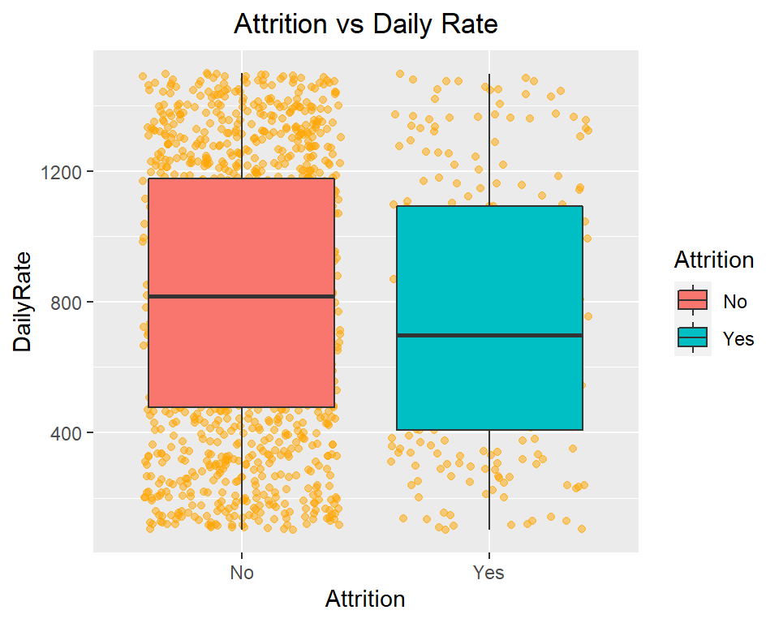

```r
#explore relationship between Attrition and Daily Rate
EmployeeData%>%
  ggplot(aes(x = Attrition, y = DailyRate))+
  geom_point(color="orange", position="jitter", alpha=.5) +
  geom_boxplot(aes(fill = Attrition)) +
  labs(title="Attrition vs Daily Rate")+
  theme(plot.title = element_text(hjust = 0.5))
```

Then, explore the relationship between Employee Attrition (Attrition) and Employee’s education level (1= Below College, 2= College, 3= Bachelor, 4= Master, 5= Doctor). Calculate the number of employees according to their education level and whether levaing the company. The summary table is shown as below.

```r
#explore relationship between Attrition and Education
Education_df<-EmployeeData%>%
  group_by(Attrition, Education)%>%
  summarise(totalnum=n())

Education_df
```

```
## # A tibble: 10 x 3
## # Groups:   Attrition [2]
##    Attrition Education totalnum
##    <chr>         <dbl>    <int>
##  1 No                1      139
##  2 No                2      238
##  3 No                3      473
##  4 No                4      340
##  5 No                5       43
##  6 Yes               1       31
##  7 Yes               2       44
##  8 Yes               3       99
##  9 Yes               4       58
## 10 Yes               5        5
```

Plot the above table in a histogram, which is shown as below. We can observe that the number of employees with a bachelor’s degree is the highest, the number of employees with a master’s degree is the second highest, and the number of employees with a college degree is next. The number of employees who leave the company among different education levels are all very low. There is not a significant relation between employee’s education level and whether they leave the company.

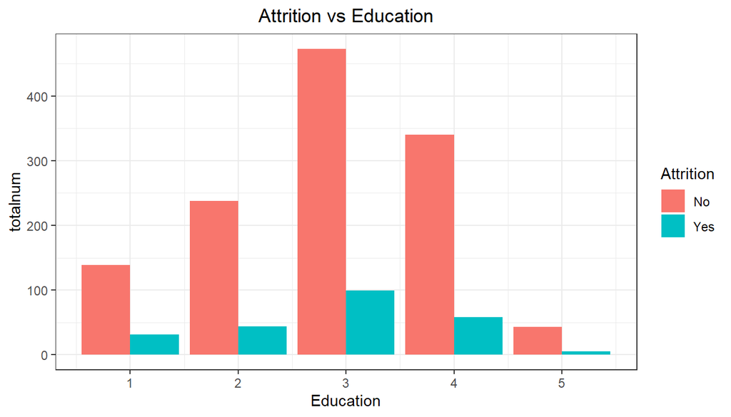

```r
#explore
Education_df%>%
  ggplot(aes(x=Education, y=totalnum, fill=Attrition))+
  geom_bar(stat = "identity",position = "dodge")+
  theme_bw()+
  labs(title="Attrition vs Education")+
  theme(plot.title = element_text(hjust = 0.5))
```

Next, explore the relationship among Employee’s education level, Employee Attrition (Attrition) and Salary level of employee (DailyRate). Generate a boxplot using these three variables, which is shown as below.

It can be observed that there is no significant difference in the salary level of employees among different levels of education. When the education level is the same, the salary level of employees who not leaving the company are a bit higher than the salary level of employees who leaving the company. Thus, we can infer that unsatisfied with salary level is one of the reasons for employees leaving the company.

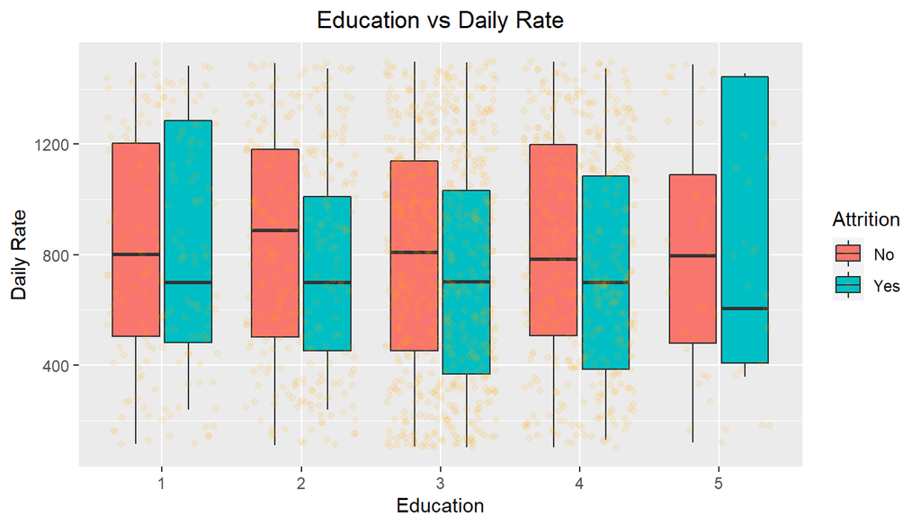

```r
EmployeeData%>%
  ggplot(aes(x = as.factor(Education), y = DailyRate, fill=Attrition))+
  geom_boxplot()+
  xlab("Education")+
  ylab("Daily Rate")+
  geom_point(color="orange", position="jitter", alpha=.1) +
  labs(title="Education vs Daily Rate")+
  theme(plot.title = element_text(hjust = 0.5))
```

Then, explore the relationship between Employees Job Satisfaction (1=Low, 2=Medium, 3=High, 4=Very High) and Employee Attrition (Attrition). Calculate the number of employees according to their job satisfaction level and whether levaing the company. The summary table is shown as below.

```r
Job_Stf_df<-EmployeeData%>%
  group_by(Attrition, JobSatisfaction)%>%
  summarise(totalnum=n())

Job_Stf_df
```

```
## # A tibble: 8 x 3
## # Groups:   Attrition [2]
##   Attrition JobSatisfaction totalnum
##   <chr>               <dbl>    <int>
## 1 No                      1      223
## 2 No                      2      234
## 3 No                      3      369
## 4 No                      4      407
## 5 Yes                     1       66
## 6 Yes                     2       46
## 7 Yes                     3       73
## 8 Yes                     4       52
```

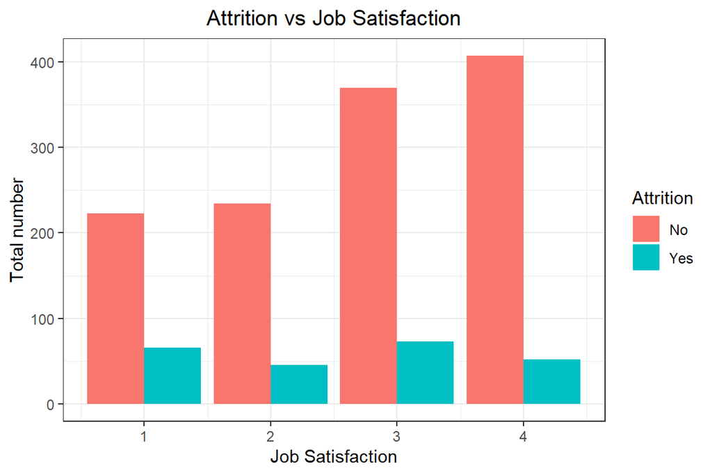

```r
#explore
Job_Stf_df%>%
  ggplot(aes(x=JobSatisfaction, y=totalnum, fill=Attrition))+
  geom_bar(stat = "identity",position = "dodge")+
  theme_bw()+
  labs(title="Attrition vs Job Satisfaction")+
  xlab("Job Satisfaction")+
  ylab("Total number")+
  theme(plot.title = element_text(hjust = 0.5))
```

Next, explore the relationship between Employee Hourly Salary (HourlyRate) and Department of employee (1=HR, 2=R&D, 3=Sales). Generate the density plot of Hourly Salary among different departments, as is shown as below.  
It can be observed that the hourly salary of R&D is highest, the hourly salary of sales is the second highest and the hourly salary of HR is the lowest.

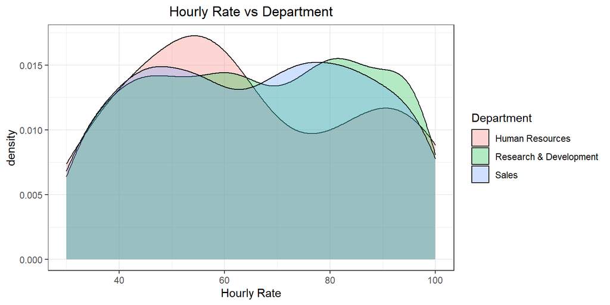

```r
EmployeeData%>%
  ggplot(aes(x=HourlyRate,  fill=Department))+
  geom_density(alpha=.3)+
  theme_bw()+
  labs(title="Hourly Rate vs Department")+
  xlab("Hourly Rate")+
  theme(plot.title = element_text(hjust = 0.5))
```

Finally, explore the relationship among Employee’s gender, Employee Attrition (Attrition) and Employee’s Monthly salary (MonthlyRate). Generate a boxplot using these three variables, which is shown as below. It can be observed that there is no significant difference in the Employee’s Monthly salary level between male and female. There is also no significant difference in whether Employee leaving the company between male and female.

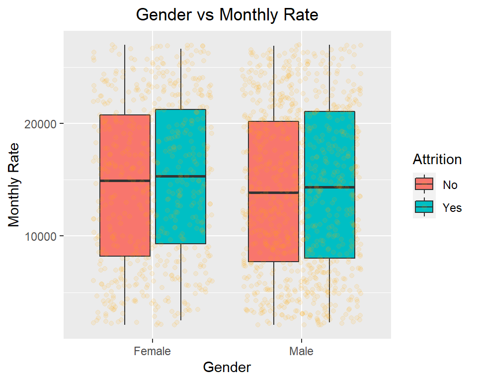

```r
#explore
EmployeeData%>%
  ggplot(aes(x = Gender, y = MonthlyRate, fill=Attrition))+
  geom_boxplot()+
  xlab("Gender")+
  ylab("Monthly Rate")+
  geom_point(color="orange", position="jitter", alpha=.1) +
  labs(title="Gender vs Monthly Rate")+
  theme(plot.title = element_text(hjust = 0.5))
```

## Feature Extraction

After transformation, there are 55 variables in total. The first 6 rows of the new data is shown as below.

```r
Subset_numeric<-select_if(EmployeeData,is.numeric)

BusinessTravel_df<-model.matrix(~BusinessTravel-1,EmployeeData) %>% as.data.frame()
Department_df<-model.matrix(~Department-1,EmployeeData) %>% as.data.frame()
EducationField_df<-model.matrix(~EducationField-1,EmployeeData) %>%as.data.frame()
Gender_df<-model.matrix(~Gender-1,EmployeeData) %>% as.data.frame()
JobRole_df<-model.matrix(~JobRole-1,EmployeeData) %>% as.data.frame()
MaritalStatus_df<-model.matrix(~MaritalStatus-1,EmployeeData) %>% as.data.frame()
OverTime_df<-model.matrix(~OverTime-1,EmployeeData) %>% as.data.frame()

EmployeeNew<-cbind(Subset_numeric, BusinessTravel_df, Department_df,
                    EducationField_df, Gender_df, JobRole_df,
                    MaritalStatus_df, OverTime_df)

EmployeeNew$Attrition<-EmployeeData$Attrition

dim(EmployeeNew)
```

```
## [1] 1470   55
```

```r
head(EmployeeNew)
```

```
##   Age DailyRate DistanceFromHome Education EmployeeCount EmployeeNumber
## 1  41      1102                1         2             1              1
## 2  49       279                8         1             1              2
## 3  37      1373                2         2             1              4
## 4  33      1392                3         4             1              5
## 5  27       591                2         1             1              7
## 6  32      1005                2         2             1              8
##   EnvironmentSatisfaction HourlyRate JobInvolvement JobLevel JobSatisfaction
## 1                       2         94              3        2               4
## 2                       3         61              2        2               2
## 3                       4         92              2        1               3
## 4                       4         56              3        1               3
## 5                       1         40              3        1               2
## 6                       4         79              3        1               4
##   MonthlyIncome MonthlyRate NumCompaniesWorked PercentSalaryHike
```

[output cut: 104 more lines]

## Data Splitting

The new data is split into a 70% training subset data and a 30% testing subset data. Stratified sampling is used according to the dependent variable Attrition (Y).

```r
EmployeeNew_split <- EmployeeNew %>%
  initial_split(prop = 0.7, strata = "Attrition")

EmployeeNew_train <- training(EmployeeNew_split)
EmployeeNew_test <- testing(EmployeeNew_split)
```

## Model Fitting

In this section, four models **Random Forest**, **Gradient Boosting model**, **Least Squares SVM** and **Model Averaged Neural Network** are fit on the training subset using 10-fold cross-validation method. For each model fitting, different tuning parameters are used and the best tuning parameter is chosen according to the “Accuracy” metric as this project focuses on a classification problem.

After choosing the best tuning parameter for each model, we will use the model to predict the Employee Attrition on the testing subset. Compare the predicted values with the actual values, we can calculate the “Accuracy” on the testing subset for all the four models and find out the optimal model in this project.

#### Random Forest

First, fit the Random Forest model on the training data using 10-fold cross-validation method. The tuning parameter of Random Forest model I use is **mtry**, which is set from 10 to 20.

```r
#train
set.seed(7321)

tc_10<-trainControl(method="cv",
                    number=10)

tg <- expand.grid(mtry=10:20)

mod.rf <- train(as.factor(Attrition) ~ .,
                 metric = "Accuracy",
                 method = "rf",
                 trControl = tc_10,
                 tuneGrid = tg,
                 data = EmployeeNew_train)
```

```r
result.rf<-data.frame(mtry=c(10:20),
                      Accuracy=mod.rf$results['Accuracy'],
                      AccuracySD=mod.rf$results['AccuracySD'],
                      cv=10)

result.rf
```

```
##    mtry  Accuracy AccuracySD cv
## 1    10 0.8589229 0.02273653 10
## 2    11 0.8627876 0.02108868 10
## 3    12 0.8608458 0.01929084 10
## 4    13 0.8627876 0.02007085 10
## 5    14 0.8598559 0.02390007 10
## 6    15 0.8617978 0.02374451 10
## 7    16 0.8608458 0.02088575 10
## 8    17 0.8618072 0.02370777 10
## 9    18 0.8627876 0.02209698 10
## 10   19 0.8637775 0.02127908 10
## 11   20 0.8608929 0.02052656 10
```

```r
#predict
set.seed(7321)

tg <- expand.grid(mtry=10)

mod.rf.pre <- train(as.factor(Attrition) ~ .,
                 metric = "Accuracy",
                 method = "rf",
                 tuneGrid = tg,
                 data = EmployeeNew_train)
```

```r
mod.rf.pre$finalModel
```

```
##
## Call:
##  randomForest(x = x, y = y, mtry = param$mtry)
##                Type of random forest: classification
##                      Number of trees: 500
## No. of variables tried at each split: 10
##
##         OOB estimate of  error rate: 13.81%
## Confusion matrix:
##      No Yes class.error
## No  855   8 0.009269988
## Yes 134  31 0.812121212
```

```r
importance.df<-data.frame(mod.rf.pre$finalModel$importance)
importance.df$variables<-rownames(importance.df)
importance.df[order(importance.df$MeanDecreaseGini, decreasing = TRUE),]
```

```
##                                    MeanDecreaseGini
## MonthlyIncome                            20.8381999
## Age                                      16.3150631
## TotalWorkingYears                        14.5388633
## DailyRate                                14.4170700
## EmployeeNumber                           13.5544402
## MonthlyRate                              12.6801889
## DistanceFromHome                         12.3447511
## HourlyRate                               12.2088960
## YearsAtCompany                           10.1841538
## YearsWithCurrManager                      9.1455368
## PercentSalaryHike                         8.1869330
## OverTimeNo                                8.1191537
## OverTimeYes                               7.9512524
## NumCompaniesWorked                        7.8567629
## EnvironmentSatisfaction                   7.8516203
## StockOptionLevel                          7.6158578
## JobSatisfaction                           7.2320118
## WorkLifeBalance                           6.6775217
## YearsSinceLastPromotion                   6.2426993
## JobLevel                                  5.9400800
## YearsInCurrentRole                        5.9305694
## TrainingTimesLastYear                     5.7478601
## JobInvolvement                            5.5159885
## RelationshipSatisfaction                  5.4996438
## Education                                 4.3781890
## MaritalStatusSingle                       4.2785354
## BusinessTravelTravel_Frequently           3.0091738
## `JobRoleLaboratory Technician`            2.7169698
## DepartmentSales                           1.9929310
## `EducationFieldTechnical Degree`          1.8756984
## EducationFieldMedical                     1.7970197
## `JobRoleSales Executive`                  1.7908541
## BusinessTravelTravel_Rarely               1.7708424
## `JobRoleSales Representative`             1.7686465
## EducationFieldMarketing                   1.6976828
## `EducationFieldLife Sciences`             1.6924321
## GenderMale                                1.6874592
## GenderFemale                              1.5987292
## MaritalStatusMarried                      1.5892733
```

[output cut: 55 more lines]

```
## `DepartmentResearch & Development` `DepartmentResearch & Development`
## `JobRoleResearch Scientist`               `JobRoleResearch Scientist`
## MaritalStatusDivorced                           MaritalStatusDivorced
## PerformanceRating                                   PerformanceRating
## `JobRoleHuman Resources`                     `JobRoleHuman Resources`
## `BusinessTravelNon-Travel`                 `BusinessTravelNon-Travel`
## `DepartmentHuman Resources`               `DepartmentHuman Resources`
## `JobRoleHealthcare Representative` `JobRoleHealthcare Representative`
## `JobRoleManufacturing Director`       `JobRoleManufacturing Director`
## EducationFieldOther                               EducationFieldOther
## `EducationFieldHuman Resources`       `EducationFieldHuman Resources`
## JobRoleManager                                         JobRoleManager
## `JobRoleResearch Director`                 `JobRoleResearch Director`
## EmployeeCount                                           EmployeeCount
## StandardHours                                           StandardHours
```

```r
rf.pre.result<-predict(mod.rf.pre, newdata = EmployeeNew_test)

mean(EmployeeNew_test$Attrition==rf.pre.result)
```

```
## [1] 0.8529412
```

#### Gradient Boosting model

Second, fit the Gradient Boosting model on the training data using 10-fold cross-validation method. The tuning parameter of Gradient Boosting model is **n.trees**, which is set 100, 200, 300, 400, 500.

```r
#train

#Gradient Boosting

library(gbm)
library(plyr)
set.seed(7321)
tc_10<-trainControl(method="cv",
                    number=10)

tg <- expand.grid(n.trees = c(100,200,300,400,500),
                  interaction.depth = 5,
                  shrinkage = 0.2,
                  n.minobsinnode = 10)

mod.gb1 <- train(as.factor(Attrition) ~ .,
                 metric = "Accuracy",
                 method = "gbm",
                 trControl = tc_10,
                 tuneGrid = tg,
                 data = EmployeeNew_train)
```

```r
result.gb1<-data.frame(n.trees = c(100,200,300,400,500),
                      Accuracy=mod.gb1$results['Accuracy'],
                      AccuracySD=mod.gb1$results['AccuracySD'],
                      cv=10)

result.gb1
```

```
##   n.trees  Accuracy AccuracySD cv
## 1     100 0.8763902 0.02506375 10
## 2     200 0.8744294 0.03055434 10
## 3     300 0.8676234 0.03614347 10
## 4     400 0.8637777 0.03206810 10
## 5     500 0.8667095 0.03626022 10
```

```r
#predict
set.seed(7321)

tg <- expand.grid(n.trees = 400,
                  interaction.depth = 5,
                  shrinkage = 0.2,
                  n.minobsinnode = 10)


mod.gbl.pre <- train(as.factor(Attrition) ~ .,
                 metric = "Accuracy",
                 method = "gbm",
                 tuneGrid = tg,
                 data = EmployeeNew_train)
```

```r
gbl.pre.result<-predict(mod.gbl.pre, newdata = EmployeeNew_test)
mean(EmployeeNew_test$Attrition==gbl.pre.result)
```

```
## [1] 0.8484163
```

#### Least Squares Support Vector Machine with Radial Basis Function Kernel

Third, fit the Least Squares Support Vector Machine model with Radial Basis Function Kernel on the training data using 10-fold cross-validation method. The tuning parameter of this model is **tau**, which is set 0, 0.5, 1, 5, 10.

```r
library(kernlab)
#train

#Least Squares Support Vector Machine

set.seed(7321)
tc_10<-trainControl(method="cv",
                    number=10)

tg <- expand.grid(tau = c(0, 0.5, 1, 5, 10),
                  sigma=1)

mod.svm <- train(as.factor(Attrition) ~ .,
                 metric = "Accuracy",
                 method = "lssvmRadial",
                 trControl = tc_10,
                 tuneGrid = tg,
                 data = EmployeeNew_train)
```

Extract the accuracy percentages and standard deviations for each cv and each tau, and the result is shown as below. It can be observed that for all different tau, accuracy is the same.

```r
result.svm<-data.frame(tau = c(0, 0.5, 1, 5, 10),
                      Accuracy=mod.svm$results['Accuracy'],
                      AccuracySD=mod.svm$results['AccuracySD'],
                      cv=10)

result.svm
```

```
##    tau  Accuracy  AccuracySD cv
## 1  0.0 0.8395141 0.004205199 10
## 2  0.5 0.8395141 0.004205199 10
## 3  1.0 0.8395141 0.004205199 10
## 4  5.0 0.8395141 0.004205199 10
## 5 10.0 0.8395141 0.004205199 10
```

Set tau = 1, and use this Least Squares SVM model to predict on the testing data.

```r
#predict
set.seed(7321)

tg <- expand.grid(tau = 1, sigma=1)


mod.svm.pre <- train(as.factor(Attrition) ~ .,
                 metric = "Accuracy",
                 method = "lssvmRadial",
                 tuneGrid = tg,
                 data = EmployeeNew_train)
```

For this Least Squares SVM model, We can see that the Accuracy on the testing subset is 0.8371041.

```r
svm.pre.result<-predict(mod.svm.pre, newdata = EmployeeNew_test)
mean(EmployeeNew_test$Attrition==svm.pre.result)
```

```
## [1] 0.8371041
```

#### Model Averaged Neural Network

Finally, fit the Averaged Neural Network model on the training data using 10-fold cross-validation method. The tuning parameter of this model is **size**, which is set 3, 4, 5, 6, 7.

```r
library(nnet)
#train

#Model Averaged Neural Network

set.seed(7321)
tc_10<-trainControl(method="cv",
                    number=10)

tg <- expand.grid(size = c(3, 4, 5, 6, 7),
                  decay=0,
                  bag=FALSE)

mod.nn <- train(as.factor(Attrition) ~ .,
                 metric = "Accuracy",
                 method = "avNNet",
                 trControl = tc_10,
                 tuneGrid = tg,
                 data = EmployeeNew_train)
```

[output not shown]

[output cut: 455 more lines]

[output not shown]

Extract the accuracy percentages and standard deviations for each cv and each size, and the result is shown as below. It can be observed that for all different size, accuracy is the same.

```r
result.nn<-data.frame(size = c(3, 4, 5, 6, 7),
                      Accuracy=mod.nn$results['Accuracy'],
                      AccuracySD=mod.nn$results['AccuracySD'],
                      cv=10)

result.nn
```

```
##   size  Accuracy  AccuracySD cv
## 1    3 0.8395141 0.004205199 10
## 2    4 0.8395141 0.004205199 10
## 3    5 0.8395141 0.004205199 10
## 4    6 0.8395141 0.004205199 10
## 5    7 0.8395141 0.004205199 10
```

Set size= 3, and use this Averaged Neural Network model to predict on the testing data.

```r
#predict
set.seed(7321)

tg <- expand.grid(size = 3,
                  decay=0,
                  bag=FALSE)


mod.nn.pre <- train(as.factor(Attrition) ~ .,
                 metric = "Accuracy",
                 method = "avNNet",
                 tuneGrid = tg,
                 data = EmployeeNew_train)
```

[output not shown]

[output cut: 205 more lines]

[output not shown]

For this Averaged Neural Network model, We can see that the Accuracy on the testing subset is 0.8371041.

```r
nn.pre.result<-predict(mod.nn.pre, newdata = EmployeeNew_test)
mean(EmployeeNew_test$Attrition==nn.pre.result)
```

```
## [1] 0.8371041
```

## Result & conclusion

```r
result_df<-data.frame(method=c("Random Forest",
                               "Gradient Boosting",
                               "Least Squares SVM",
                               "Model Averaged Neural Network"),
                      accuracy=c(mean(EmployeeNew_test$Attrition==rf.pre.result),
                                 mean(EmployeeNew_test$Attrition==gbl.pre.result),
                                 mean(EmployeeNew_test$Attrition==svm.pre.result),
                                 mean(EmployeeNew_test$Attrition==nn.pre.result)))

result_df
```

```
##                          method  accuracy
## 1                 Random Forest 0.8529412
## 2             Gradient Boosting 0.8484163
## 3             Least Squares SVM 0.8371041
## 4 Model Averaged Neural Network 0.8371041
```